# R for Beginners: plotting data

C. Tobin Magle

Jan 11, 2017

This material was adapted from the Software Carpentry [Inflammation](http://swcarpentry.github.io/r-novice-inflammation/01-starting-with-data.html) and Gapminder lessons. This document and associated script can be found at https://github.com/maglet/r-for-beginners

#### Plotting data

Lastly, we’re going to look at how to plot these data. The R base graphics package has many options for plotting your data. Many people prefer more advanced packages, such as [ggplot2](http://zevross.com/blog/2014/08/04/beautiful-plotting-in-r-a-ggplot2-cheatsheet-3/), but we will stick to the base package here for simplicity’s sake.

We’ll be working with **histograms**, **bar plots**, **box plots**, **scatter plots**, and **a basic plot with colorization by factors**.

First, let’s look at the distribution of values of life expenctancy, and just for kicks, we’ll make the bars blue. Make sure to label the axes!

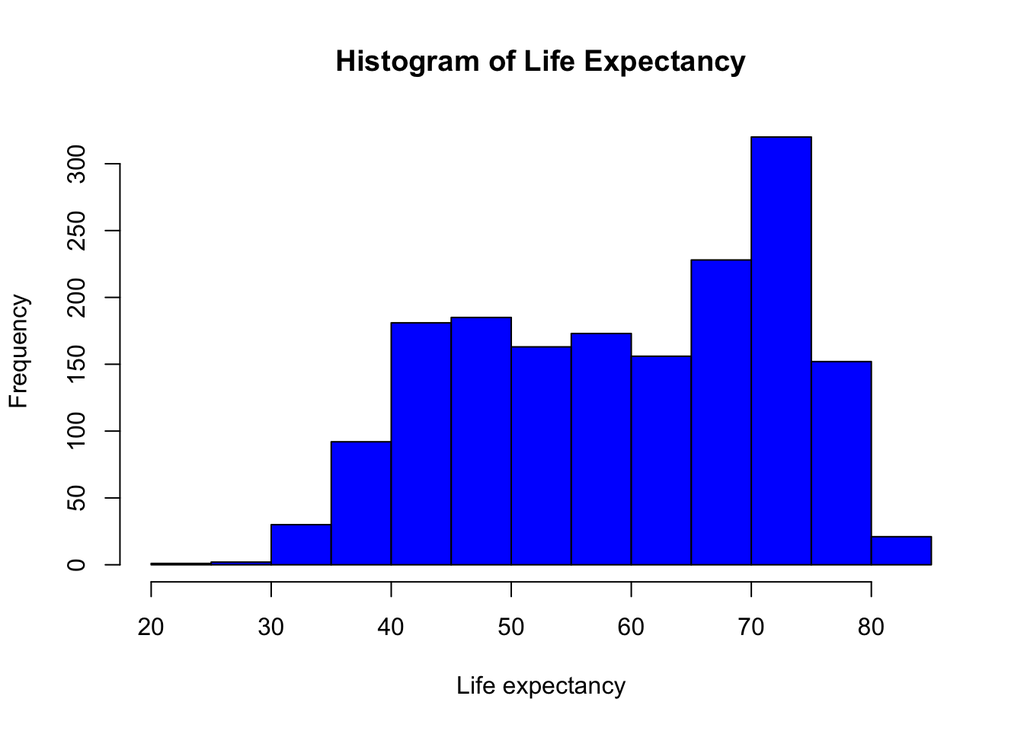

```r
hist(x=gapminder$lifeExp,    #plots life expectancy for all countries in all years
     main="Histogram of Life Expectancy", #main title
     xlab="Life expectancy",                        #x axis label
     ylab="Frequency",                                 #y axis label
     col="blue")                                       #color
```

This allows you to see how your data are distributed. Remember how hard it is to [make a histogram in Excel](https://support.microsoft.com/en-us/kb/214269)? That’s a thing of the past for you now.

Now let’s look at making a bar chart of the average life expectancy for each continent. First, we have to generate this value for each continent. For that we will need to use a for loop:

```r
continents<-levels(gapminder$continent) #create a list of continents
heights<-NULL                           #make an empty variable that will store heights
sds<-NULL                               #make an empty variable that will store sds for error bars

for(i in continents){                        #for every continent
       sub<-subset(gapminder, continent==i)  #make a subset with only that continent
       avg<-mean(sub$lifeExp)                #take the average life exp for that continent
       sd<-sd(sub$lifeExp)                   #take the sd of life exp for that continent
       heights<-append(heights, avg)         #add this value to the list of avg life exp
       sds<-append(sds, sd)                  #add this value to the list of avg life exp
}
```

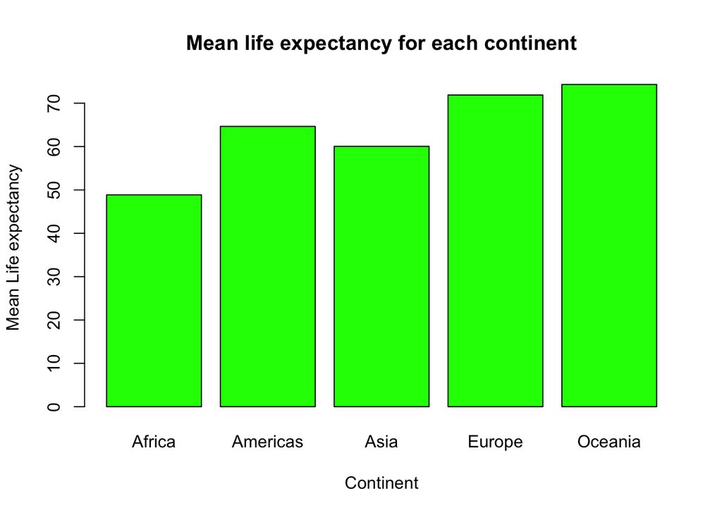

```r
barplot(height=heights,                                  #height of the bars
        main="Mean life expectancy for each continent",  #main graph title
        xlab="Continent",                                #x axis label
        ylab="Mean Life expectancy",                     #y axis label
        names.arg = continents,                          #specify bar labels
        col="green")                                     #green bars
```

But wait, where are the error bars? This requires some extra code.

A great way to find code is to look at R blogs. I found some code to make box plots [here](http://monkeysuncle.stanford.edu/?p=485) and adapted it to our purposes.

Here’s a function to plot the error bars. I didn’t need to change anything here, because we’ll provide our arguments during the function call.

```r
error.bar <- function(x, # the bar plot
                      y, #daily means
                      upper, #standard deviation
                      lower=upper, #error bars in both directions
                      length=0.1,...) #length of the arrow head (in inches)
{
     if(length(x) != length(y) | length(y) !=length(lower) | length(lower) != length(upper))
          stop("vectors must be same length")
     arrows(x0=x,            #point to draw the arrow from (x)
            y0=y+upper,      #                             (y)
            x1=x,            #                        to (x)
            y1=y-lower,      #                        to (y)
            angle=90,        #draw it at a 90 degree angle
            code=3,          #choose type of arrow
            length=length,   #length of the arrow head (inches)
            ...)             #sends graphics paramenters from the function call
}
```

Now there is a function called **error.bar** in your environment.

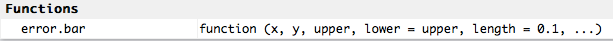

Now I replaced their randomly generated variables with the ones that we want to plot in the function call.

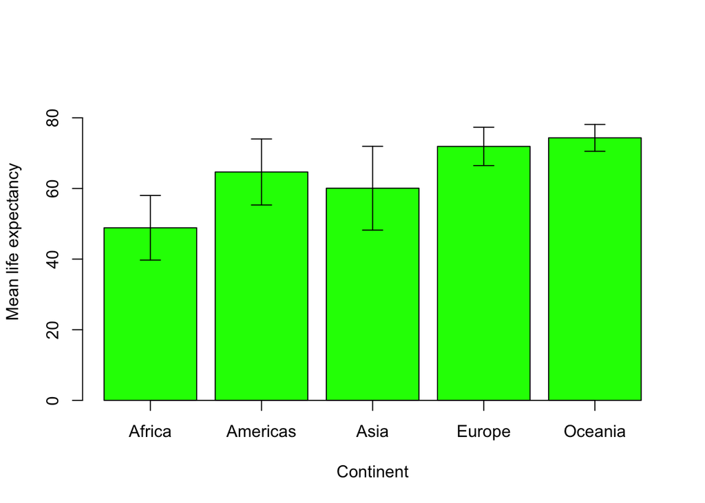

```r
#This command draws the plot w/o error bars
barx <- barplot(height=heights,                 #height of the bars
                names.arg = continents,                          #specify bar labels
                ylim=c(0,90),        #y axis range, determined by tweaking
                col="green",          #blue bars
                axis.lty=1,          #choose line type (opaque) for y axis
                xlab="Continent",                #x axis label
                ylab="Mean life expectancy") #y axis label

#this function draws the error bars
error.bar(barx, heights, sds)
```

Now let’s draw a box plot for population, separating the data based on continent.

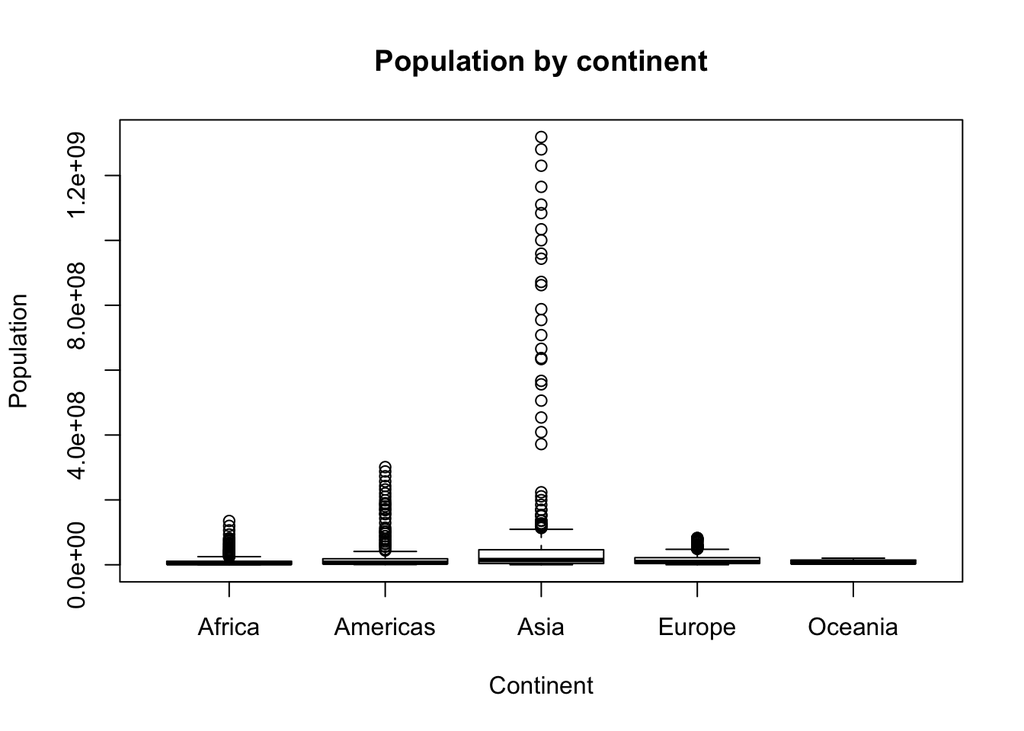

```r
          #Data to plot      #factor to separate on
boxplot(gapminder$pop ~ gapminder$continent,
        main="Population by continent",
        ylab="Population",
        xlab="Continent")
```

Wow, Asia and the Americas have outliers. We can zoom on on the box plot ysing the y lim parameter.

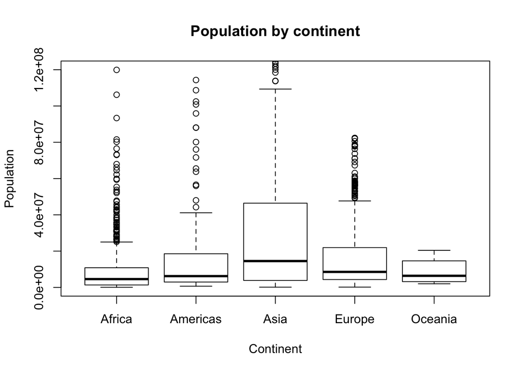

```r
          #Data to plot      #factor to separate on
boxplot(gapminder$pop ~ gapminder$continent,
        main="Population by continent",
        ylab="Population",
        xlab="Continent",
        ylim=c(0,1.2e+08))
```

We can also make a scatter plot of 2 variables:

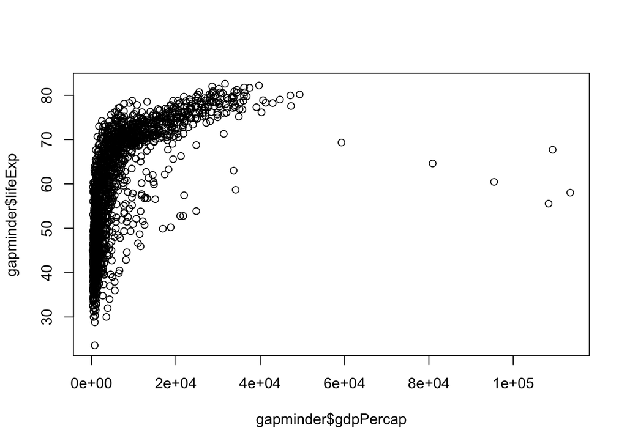

```r
plot(gapminder$gdpPercap, gapminder$lifeExp)
```

Let’s see which of these data points are from which continenr using the col command. I also altered some other useful base graphics packages to get the image ready for publication:

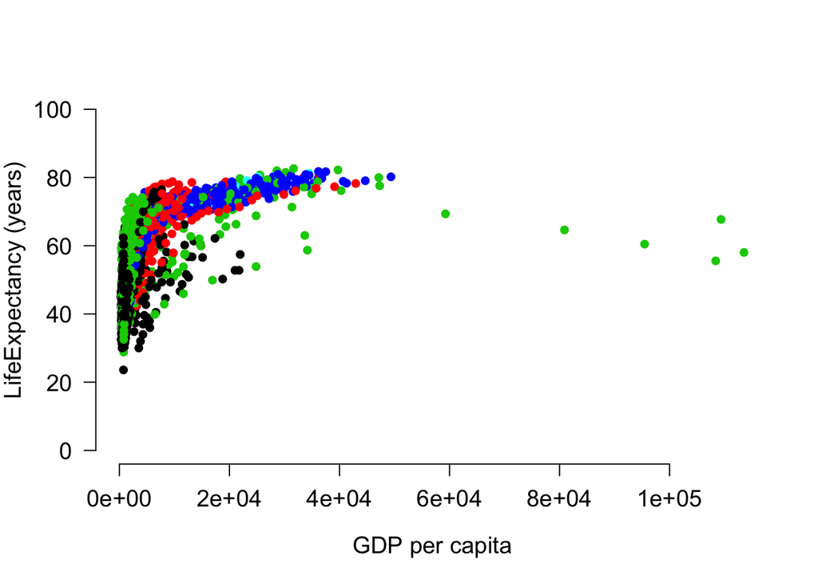

```r
plot(gapminder$gdpPercap, gapminder$lifeExp,
     xlab="GDP per capita",        #X axis label
     ylab= "LifeExpectancy (years)",    #Y axis label (somehow get )
     las= 1,                  #Make numbers horizontal on the x axis,
     cex.lab=1.2,             #Increase axis labels font size
     cex.axis=1.2,            #Increase axis label number size
     lwd=2,                   #Increase line/dot thickness
     bty = "n",               #removes black border around the plot
     pch=16,                  #Specifies symbols to draw
     ylim= c(0,100),            #set y axis limits
     col = gapminder$continent) #Set Color based on Continent
```

But how do we know which go to which continent? A figure legend would help:

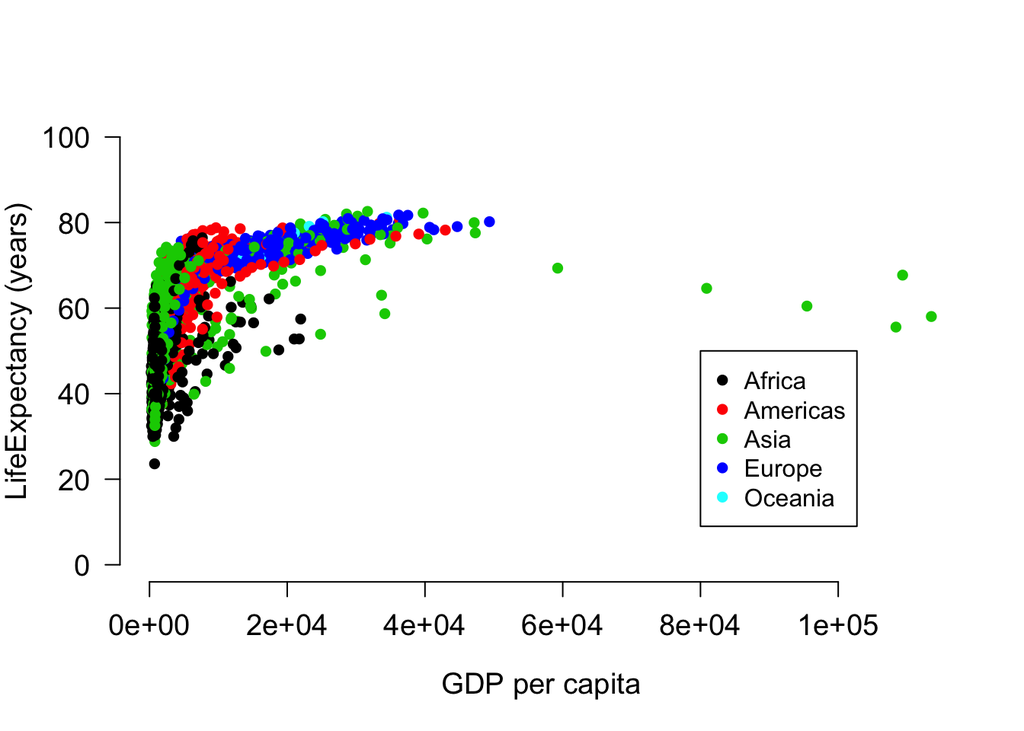

```r
plot(gapminder$gdpPercap, gapminder$lifeExp,
     xlab="GDP per capita",        #X axis label
     ylab= "LifeExpectancy (years)",    #Y axis label (somehow get )
     las= 1,                  #Make numbers horizontal on the x axis,
     cex.lab=1.2,             #Increase axis labels font size
     cex.axis=1.2,            #Increase axis label number size
     lwd=2,                   #Increase line/dot thickness
     bty = "n",               #removes black border around the plot
     pch=16,                  #Specifies symbols to draw
     ylim= c(0,100),            #set y axis limits
     col = gapminder$continent) #Set Color based on Continent

legend(x= 8e+04,                                #x position of legend
       y=50,                                #y position of legend
       legend=levels(gapminder$continent),  #Legend text
       col = c(1:5),
       pch=16)                              #specifies how to draw symbols
```

We can also edit the axis labels to make them prettier:  
* tell the original plot not to plot an axis using xaxt = ‘n’ * draw an axis using the axis function * make sure to change the xlab to reflect the changes

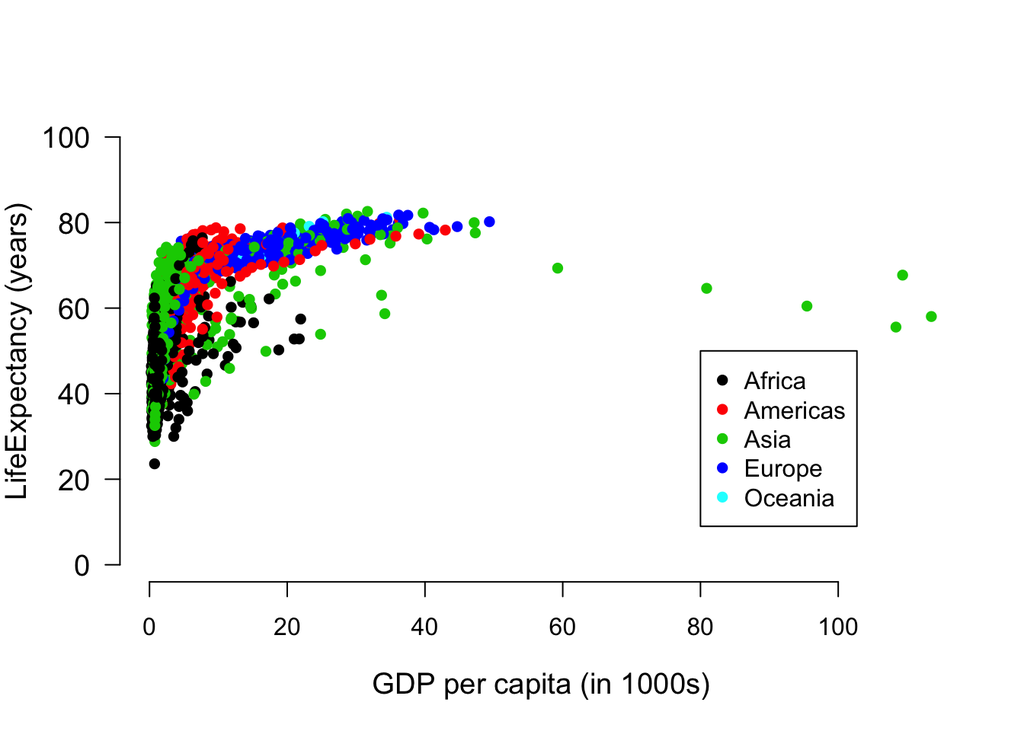

```r
plot(gapminder$gdpPercap, gapminder$lifeExp,
     xlab="GDP per capita (in 1000s)",        #X axis label
     ylab= "LifeExpectancy (years)",    #Y axis label (somehow get )
     las= 1,                  #Make numbers horizontal on the x axis,
     cex.lab=1.2,             #Increase axis labels font size
     cex.axis=1.2,            #Increase axis label number size
     lwd=2,                   #Increase line/dot thickness
     bty = "n",               #removes black border around the plot
     pch=16,                  #Specifies symbols to draw
     ylim= c(0,100),            #set y axis limits
     xaxt='n',                 #remove x axis label
     col = gapminder$continent) #Set Color based on Continent

legend(x= 8e+04,                                #x position of legend
       y=50,                                #y position of legend
       legend=levels(gapminder$continent),  #Legend text
       col = c(1:5),
       pch=16)                              #specifies how to draw symbols

axis(side=1,
     at = c(0, 2e+04, 4e+04, 6e+04, 8e+04, 1e+05),
     labels=c(0, 20, 40, 60, 80, 100))
```

### Take home points

- The R base graphics package allows you to make histograms, bar plots, box plots, and scatter plots
- These plots can be colorized based on factors
- grapics parameters can be used to alter the look of the plot

### Challenge questions

#### Consider the scatter plot of GDP vs. life expectancy.

1. How would you include only data from 2007? (remember subsetting)
2. How would you change the data to log axis? (Hint: look at the arguments)
3. How would you make a similar plot from European countries, and colorize by year?
4. Make a red histogram of population for all countries in 2007

# Resources

Congrats! Now you can plot tabular data in R! If you want to learn more, see these resources:

- [Installing packages](http://web.cs.ucla.edu/~gulzar/rstudio/)
- [swirl: Learn R in R](http://swirlstats.com)
- [R base grapics: an idiot’s guide](http://rstudio-pubs-static.s3.amazonaws.com/7953_4e3efd5b9415444ca065b1167862c349.html)
- [ggplot2](http://zevross.com/blog/2014/08/04/beautiful-plotting-in-r-a-ggplot2-cheatsheet-3/)
- [Elementary statistics with R](http://www.r-tutor.com/elementary-statistics)
- [Software Carpentry](http://software-carpentry.org)
- [Data Carpentry](http://www.datacarpentry.org)